# Do the numbers agree? A data audit of the 2025-26 Atlantic 10 season

Ian Kachadorian

**The question.** Every game produces three records of the same events: the play-by-play log, the team box score and the player box score. If the data is right, all three agree. I pulled the public ESPN data for every game an Atlantic 10 team played in 2025-26 (335 games, 157,377 play-by-play events) and counted each one against the others, the same way a stock count is reconciled against the ledger.

**The answer.** The data is good but not clean. Of 115,846 comparisons, 660 disagree, and 165 of 335 games reconcile completely. Scoring is exact: points, made threes and made free throws match in every team-game. The errors sit in the judgment stats, and one stat, assists, accounts for 51% of them.

## What I found

1. **Assists are the weak point.** Play-by-play assists match the team box score in only 79.1% of team-games; every other stat matches in 97.3% or more. The play-by-play is short by a net 173 assists over the season.
2. **The assist gap depends on where the game was played.** In games hosted by St. Bonaventure, 47% of team-games have an assist mismatch. In games hosted by Rhode Island, it is 3%. That points to how each arena’s scoring crew enters assists, not to random error. I have not confirmed the cause; the pattern is what the data shows.
3. **It changes a ranking.** By the box score, St. Bonaventure was 2nd in the conference in assists per game (15.7). Counted from play-by-play, they drop to 4th (15.0). Any lineup or on/off assist number built from play-by-play carries that error.
4. **One game holds 13% of all mismatches.** St. Bonaventure 83, Ohio 88 (2025-12-13) has 83 on its own: missing three-point attempts, turnovers, steals and fouls for both teams, which looks like a stretch of the game missing from the feed.
5. **The obvious sort key is wrong.** Sorting events by `sequence_number` puts them out of game order in 284 of 335 games (918 places where the clock runs backward). Sorting by `game_play_number` is correct in every game. Anyone computing lineups or runs from the wrong column gets wrong answers without an error message.

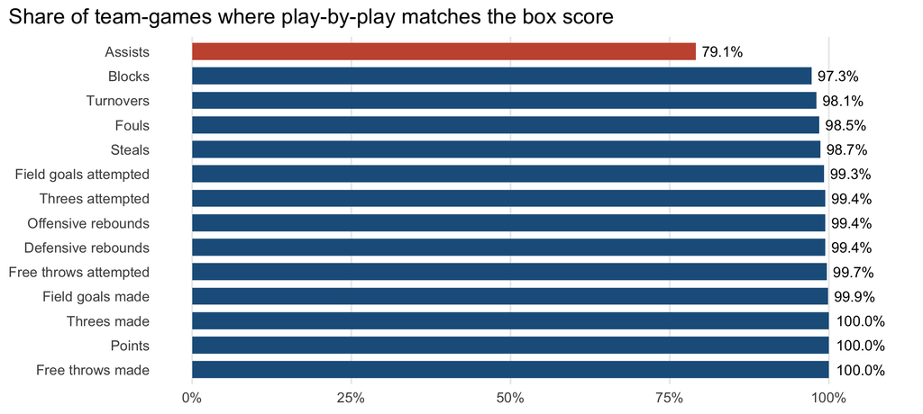

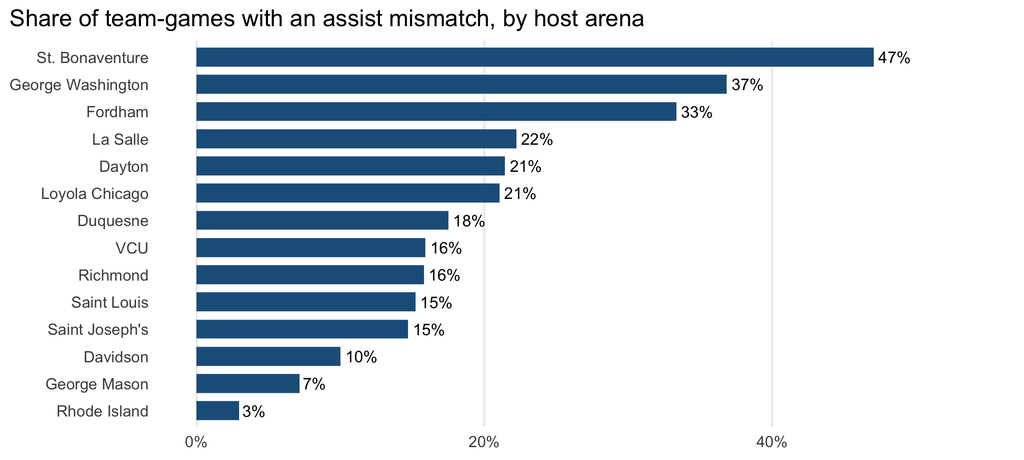

## The checks

| Check | Comparisons | Mismatches | Match rate | Games affected |
| --- | --- | --- | --- | --- |
| Box score arithmetic | 2,010 | 1 | 99.95% | 1 |
| Play-by-play vs player box | 95,746 | 422 | 99.56% | 152 |
| Play-by-play vs team box | 9,380 | 210 | 97.76% | 137 |
| Player box sum vs team box | 8,040 | 26 | 99.68% | 25 |
| Player minutes vs game length | 670 | 1 | 99.85% | 1 |

- **Play-by-play vs team box:** 14 stats per team per game, counted from events and compared with the official team line.
- **Play-by-play vs player box:** the same stats for each player.
- **Player box sum vs team box:** the player lines must add up to the team line.
- **Player minutes vs game length:** 200 team minutes, plus 25 for each overtime.
- **Box score arithmetic:** points equal twos, threes and free throws; total rebounds equal offensive plus defensive; each team’s opponent score equals the opponent’s own score.

## Limits

This is public ESPN data loaded with the `hoopR` package, not CBB Analytics’ own feed, so the specific errors may differ from yours. The scores in this play-by-play were rebuilt by `hoopR`, so the running score cannot be tested independently. A mismatch shows that two records disagree; it does not show which one is right. That takes film or the official scorer’s report.

The method carries over to any feed. Every mismatch is listed by game, team and player in `output/discrepancies.csv` and in the app (`app.R`).